# My Simple Logistic Regression

## Background

“The General Social Survey (GSS) conducts basic scientific research on the structure and development of American society with a data-collection program designed to both monitor societal change within the United States and to compare the United States to other nations.”[$^1$](http://www3.norc.org/GSS+Website/)

This survey is given to random adults varying in age every couple of years and provides answers to many different questions.

We are going to be looking at the question as to how likely an individual is to make an effort towards starting a new job within the next year? A sample of the data is shown in the table below.

```r
gss1 <- select(GSS, c(id, year, age, trynewjb))
datatable(gss1, options=list(lengthMenu = c(3,10,25)), extensions="Responsive")
```

|  | id | year | age | trynewjb |
| --- | --- | --- | --- | --- |
| 1 | 1 | 2012 | 22 | 3 |
| 2 | 2 | 2012 | 21 | 3 |
| 3 | 3 | 2012 | 42 | 2 |
| 4 | 4 | 2012 | 49 | 0 |
| 5 | 5 | 2012 | 70 | 0 |
| 6 | 6 | 2012 | 50 | 0 |
| 7 | 7 | 2012 | 35 | 0 |
| 8 | 8 | 2012 | 24 | 0 |
| 9 | 9 | 2012 | 28 | 0 |
| 10 | 10 | 2012 | 28 | 1 |

[output cut: 1964 more lines]

The values in the trynewjb column represent the likeliness of the individual to make an effort towards a new job with 1 representing “Very likely” and 3 representing “Not at all likely.”

## Logistic Model

A model to show the probability that an individuals willingness to make an effort to switch jobs within the year based on age could be shown by the logistic regression model:

$$P(Y_i = 1|x_i) = \frac{e^{\beta_0+\beta_1 x_i}}{1+e^{\beta_0 + \beta_1 x_i}} = \pi_i$$
where for observation $i$:

- $Y_i = 1$ denotes at least one individual making an effort towards a new job,
- $Y_i=0$ denotes no individuals making an effort toward a new job, and
- $x_i$ denotes the age of the individual.

We will test the hypothesis:

$$H_0: \beta_1 = 0 \\
H_a: \beta_1 \neq 0$$

Running the model through a logistic regession we get the following values:

```r
gss.glm <- glm(trynewjb == 1 ~ age, data = GSS, family = binomial)
pander(summary(gss.glm))
```

|  | Estimate | Std. Error | z value | Pr(>\|z\|) |
| --- | --- | --- | --- | --- |
| **(Intercept)** | -0.1569 | 0.2096 | -0.7486 | 0.4541 |
| **age** | -0.04515 | 0.005062 | -8.919 | 4.684e-19 |

(Dispersion parameter for binomial family taken to be 1 )

| Null deviance: | 1355 on 1973 degrees of freedom |
| --- | --- |
| Residual deviance: | 1259 on 1972 degrees of freedom |

Using the estimates provided in the regression above we have:

$$P(Y_i = 1|x_i) \approx \frac{e^{-0.1569 - 0.04515 x_i}}{1+e^{-0.1569 - 0.04515 x_i}} = \hat{\pi}_i$$
where $b_0 = -0.1569$ is the value of the `(Intercept)` which estimates $\beta_0$ and $b_1 = -0.04515$ is the value of `Age` which estimates $\beta_1$.

Importantly, the $p$-value for the test of `Age` shows a significant result $(p = 4.684e-19)$ giving sufficient evidence to conclude that $\beta_1 \neq 0$, which allows us to conclude that Age effects the probability of an individuals effort to look for a new job within the next year.

## A Visual of the Model

A visual of the data and its regression curve is shown below:

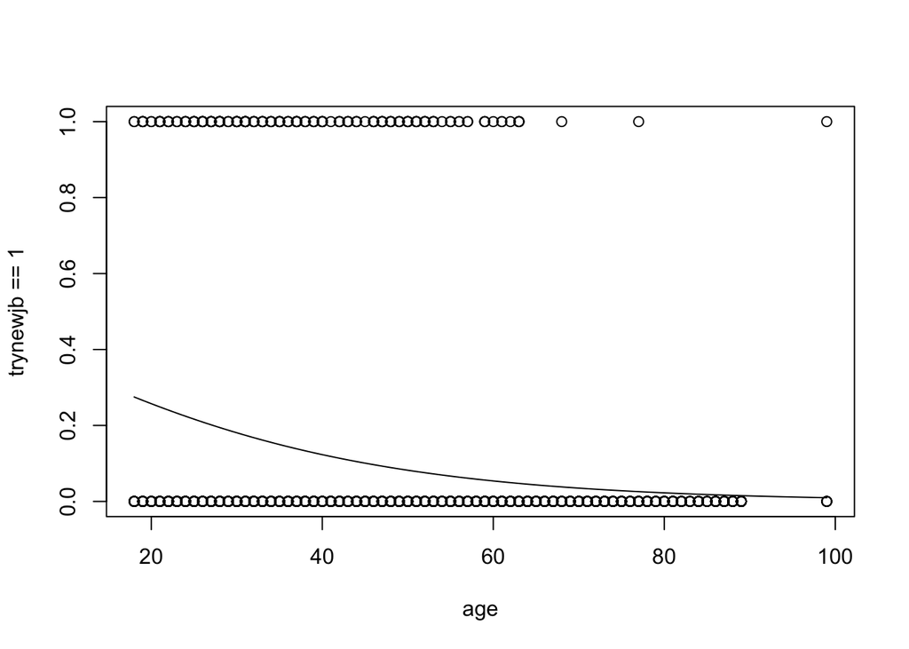

```r
plot(trynewjb == 1 ~ age, data=GSS)
curve(exp(-0.156891+(-0.045151*x))/(1+exp(-0.156891+(-0.045151*x))), add = TRUE)
```

As you can see from the plot above, there appears to be an issue with the data providing an appropriate probabilty by age.

## Appropriateness of the Model

To check and see if the Logistic Regression was appropriate for this particular data, we’ll run the data through the Hosmer-Lemeshow goodness of fit test. The results are shown below:

```r
hoslem.test(gss.glm$y, gss.glm$fitted) %>%
  pander()
```

Hosmer and Lemeshow goodness of fit (GOF) test: `gss.glm$y, gss.glm$fitted`

| Test statistic | df | P value |
| --- | --- | --- |
| 20.14 | 8 | 0.009823 * * |

With a $p$-value of 0.009823 < 0.05 level of significance. We can reasonably conclude that the Logistic Regression model is not appropriate for this data.